# Code and data style

PCB 6455 / BSC 4933: Biometry | Lecture 26

Dr. Brian Maitner

## Today’s agenda

1. The **final project**, explained
2. **Code style**: names, spaces, pipes, and letting R check you
3. **Data style**: tidy data, wide and long
4. **Pseudocode and comments**: planning code, and saying why
5. Tidy up your **Assignment 4** script before tomorrow

Type and run on a code block: type it into your script and run it. Code without the label is there to watch.

# The final project

## From here on: the final project

Assignment 4 is due **tomorrow**, Friday, November 20, 11:59 pm. After that, everything is the final project, so here it is now.

## Three parts

| Part | Format | Builds on |
| --- | --- | --- |
| **Code** | `.R`, `.Rmd` or `.qmd` (grads: a GitHub link) | every assignment so far |
| **Writing** | a document | your midterm Part 1 |
| **Presentation** | about 5 minutes, in one shared Google Slides file | the whole thing |

**Due at the presentation**, during the scheduled final exam block. Exact day and time to be confirmed.

## Part 1: the code

A **full analysis**, not a fragment:

- loading the data
- any transformations, and the reason for them
- the code behind any modeling decision you made
- the model itself
- the figures

**Fully reproducible and well documented.** Someone else should be able to run it and get your results. The rest of today is how.

## Part 2: the writing

An updated draft of your midterm writing, same three sections:

- **Introduction**: the question, and why it matters
- **Methods**: the data, and what you did to it
- **Results**: including the results of a **statistical model**, not just plots

Figures should be better than the midterm’s. You know ggplot2 now.

## Part 3: the presentation

About **five minutes**, during the final exam block, all from **one shared Google Slides file**: add your slides to it before the session. The link will be on Canvas.

A format that works:

- Title slide
- Background, 1 to 2 slides: what is your question, why does it matter
- Methods, 1 to 2 slides
- Results, 1 to 2 slides
- What you would do next

## Presenting well

- **Minimize text.** Roughly seven lines, seven words each, as an upper bound
- **Practice the timing**, out loud, with a clock
- **Going long costs points**, because it takes time from the next speaker

Your figures are the presentation. If a figure needs a paragraph of explanation, fix the figure.

## Any questions about the project?

# Code style

## Why style matters

Your code will be read by:

- **future you**, in three weeks, writing the final project
- **me**, grading Assignment 4 and the final project
- **anyone you ask for help** (Tuesday’s lecture): a forum, a labmate, a chatbot
- **reviewers and readers**, if you share it with a paper

Consistent style lets a reader see the **logic** instead of decoding the **layout**. Some style rules also prevent real bugs, as you will see.

Code is read far more often than it is written, so write it for the reader.

## Get set up

```r
library(tidyverse)
library(lintr)        # checks your style: install it first if you need to
library(styler)       # fixes your spacing: install it first if you need to
library(biometrydata)

avo <- avonet         # all 11,009 bird species, as in Lectures 23 and 24
nrow(avo)
```

**Check:** 11,009 rows.

## File names

| Rule | Good | Bad |
| --- | --- | --- |
| lowercase **snake case**: words joined by `_` | `avonet_traits.csv` | `BirdData.csv` |
| letters, numbers, `_` and `.` only | `bobwhite_counts.csv` | `Bird data?.csv` |
| describe what is inside | `clean_bobwhite.R` | `script2.R` |
| number files that run in order, with a leading 0 | `01_download.R`, `02_clean.R` | `1_download.R`, …, `10_plot.R` |
| dates as year, month, day | `avonet_clean_20261119.rds` | `avonet_clean_11-19-26.rds` |
| no “final” | `report_v2.docx` | `report_FINAL_really.docx` |

## Object names

- **Snake case**, lowercase: `parrot_data`, `mean_mass`
- Objects are **nouns**: `hawks`, `habitat_summary`
- Functions are **verbs**: `plot_wing_shape()`, `load_bbs_data()`
- **Long and clear beats short and cryptic**: autocomplete does the typing
- Related objects share a **prefix**: `avonet_parrots`, `avonet_tits`

**Quick:** name an object holding the penguins (Spheniscidae). A function that turns AVONET into family averages?

## Why names matter: three tries

```r
parrot_data <- avo |> filter(Family1 == "Psittacidae")
nrow(parrot_data)
```

```
[1] 380
```

```r
parrot-data <- avo |> filter(Family1 == "Psittacidae")
```

```
Error:
! object 'parrot' not found
```

```r
parrot data <- avo |> filter(Family1 == "Psittacidae")
# Error: unexpected symbol in "parrot data"
```

## Do not reuse R’s own names

```r
T <- 0                          # a reasonable name for a temperature...
mean(c(4, NA, 6), na.rm = T)    # ...and now na.rm = T means na.rm = 0
```

```
[1] NA
```

```r
rm(T)
```

- Write **`TRUE` and `FALSE`** in full: `T` and `F` are ordinary names anyone can overwrite
- Avoid naming things `data`, `c`, `mean` or `t`: they are already functions

## Spaces

| Do | Not |
| --- | --- |
| `a <- 1 + 2` | `a<-1+2` |
| `b <- 2^3` | `b <- 2 ^ 3` |
| `mean(x = avo$Mass, na.rm = TRUE)` | `mean( x=avo$Mass,na.rm=TRUE )` |
| `avo$Mass >= 100 & avo$Habitat == "Forest"` | `avo$Mass>=100&avo$Habitat=="Forest"` |

- Spaces around `<-`, `=`, `+`, `==`, `&` and friends; **not** around `^`, `$` or `:`
- A space **after** each comma, none just inside parentheses
- Extra spaces to **line things up** are fine

## Pipes and arguments

```r
family_summary <- avo |>
  group_by(Family1) |>
  summarise(mean_mass = mean(Mass),
            sd_mass = sd(Mass),
            mean_wing_length = mean(Wing.Length))
```

- `|>` goes at the **end** of a line, and each step starts a new line
- Named arguments that do not fit on one line get **one line each**
- Assign with `<-` at the **start**, not `->` at the end
- ggplot2’s `+` follows the **same rules** as `|>`
- A pipe longer than about **10 lines**: break it into named steps

## Sections

Long scripts need **signposts**. Ctrl+Shift+R (Cmd+Shift+R on a Mac) inserts one:

```r
# load the data ------------------------------------------------------------
```

- RStudio lists sections in the **outline** (the button at the top right of the script), so you can jump between them
- Leave a **blank line** between steps that do different things

**Try it now:** add a section label to your script for today’s code.

## Let R check your style

```r
lint(text = "MeanMass=mean(x,na.rm=T)")         # lintr: lists the problems
style_text("MeanMass=mean(x,na.rm=T)")          # styler: fixes what it can
```

| lint_says |
| --- |
| Variable and function name style should match snake_case or symbols. |
| Use one of <-, <<- for assignment, not =. |
| Put spaces around all infix operators. |
| Put a space after a comma. |
| Put spaces around all infix operators. |
| Use TRUE instead of the symbol T. |

`style_text()` gives `MeanMass <- mean(x, na.rm = T)`: spacing fixed, but **not the name or the `T`**. Those need you.

## In practice: point them at your files

Nobody types their code into `lint()`. You point it at a **script**, or a whole **folder** of them:

```r
lint("scripts/02_fit_models.R")   # one script: problems by line number
lint_dir("scripts")               # every R script in a folder

style_file("scripts/02_fit_models.R")   # restyles that file, in place
style_dir("scripts")                    # ... and every file in the folder
```

- In RStudio, the **Addins** menu has “Lint current file” and “Style active file”, for the script you have open
- `lint()` results open in the **Markers** pane: click one to jump to that line
- `style_file()` and `style_dir()` **overwrite** your files: commit or copy first

## Your turn: restyle the hawks

This works, but it is hard to read:

```r
Hawks=avo|>filter(Family1=="Accipitridae")
MeanMass<-mean(Hawks$Mass,na.rm=T)
Hawks|>group_by(Habitat)|>summarise(m=mean(Mass),w=mean(Wing.Length))->HabitatSummary
```

```r
# Open a new script (File > New File > R Script) and save it as hawks.R.
# Rewrite the three lines above in good style, with clear names.
# Then check it (or use Addins > Lint current file):
# lint("hawks.R")
```

**Check:** `lint()` finds nothing. 249 hawk species, average mass 1,244 g, a summary row for each of 8 habitats.

# Data style

## Wide and long

**Wide:** one row per species

| Species1 | Mass | Wing.Length |
| --- | --- | --- |
| Accipiter albogularis | 248.8 | 235.2 |
| Accipiter badius | 131.2 | 186.7 |

Good for entering data and reading by eye

**Long:** one row per measurement

| Species1 | trait | trait_value |
| --- | --- | --- |
| Accipiter albogularis | Mass | 248.8 |
| Accipiter albogularis | Wing.Length | 235.2 |
| Accipiter badius | Mass | 131.2 |
| Accipiter badius | Wing.Length | 186.7 |

Good for plotting many traits at once, and adding new kinds of measurement

## Tidy data

Three rules (R for Data Science, chapter 5):

1. Each **variable** is a column
2. Each **observation** is a row
3. Each **value** is a cell
- `bobwhite_counts` is tidy: one row per route per year, which is exactly what `glmer()` needed on Tuesday
- What counts as “an observation” depends on your question, so there can be more than one tidy version of the same data

Tidy data puts one observation in each row, so every tidyverse function, and every model, knows where to find things.

## Entering data: rules for spreadsheets

From Broman and Woo (2018), *Data organization in spreadsheets*, for anyone entering field or lab data:

- **Be consistent:** one code per thing (`female`, not `F`, `f` and `Female`), one name per site
- **Missing is `NA`:** never -999, and never a blank, which could be a slip
- **Dates as YYYY-MM-DD**
- **One thing per cell:** mass in one column with its unit in the column name, not “12.4 g”
- **A rectangle:** one header row, no merged cells, no calculations or graphs
- **No color or bold as data:** if a highlight means something, make it a column
- **A data dictionary:** what each column is, its units, how it was measured
- **Never edit the raw file:** save a CSV copy, back it up, and clean it in code

## Make it long: `pivot_longer()`

```r
avo_wide <- avo |>
  select(Species1, Mass, Wing.Length, Beak.Width, Beak.Length_Culmen)

avo_long <- avo_wide |>
  pivot_longer(cols = Mass:Beak.Length_Culmen,   # the columns to stack
               names_to = "trait",              # their names go here
               values_to = "trait_value")       # their values go here
avo_long
```

**Check:** 11,009 rows become 44,036: how many per species, and why?

## Why long? Every trait in one plot

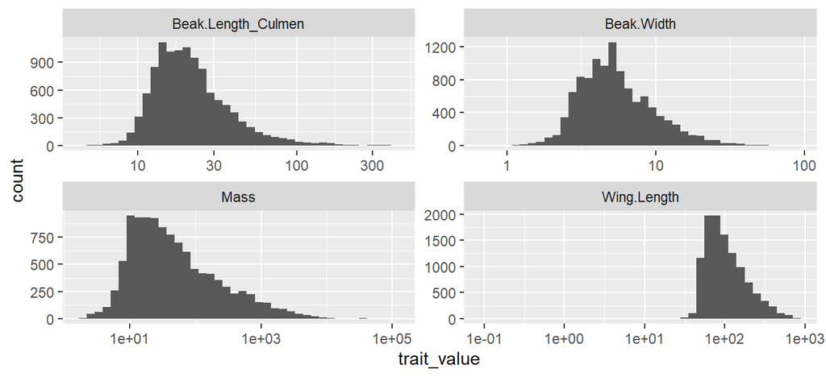

```r
ggplot(avo_long, aes(x = trait_value)) +
  geom_histogram(bins = 40) +
  scale_x_log10() +
  facet_wrap(~ trait, scales = "free")
```

## And back: `pivot_wider()`

```r
avo_wide2 <- avo_long |>
  pivot_wider(id_cols = Species1,       # what identifies a row
              names_from = trait,      # new column names come from here
              values_from = trait_value)

all.equal(as.data.frame(avo_wide2), avo_wide)
```

**Check:** `TRUE`: nothing was lost on the way there and back.

## Your turn: bobwhite, one column per year

```r
bw_wide <- bobwhite_counts |>
  select(route, year, count)
  # make it wide: one row per route, one column per year (hint: pivot_wider())

# how many cells are empty? (hint: is.na() and sum())

# for anyone fast: make bw_wide long again, with and without values_drop_na = TRUE.
# Then try pivot_wider() with only year and count selected. What goes wrong?
```

**Check:** 100 rows and 25 columns, with 1,040 empty cells. Back to long: 2,400 rows, or 1,360 with `values_drop_na = TRUE`.

**Then:** which version is easier to read by eye? Which one could `glmer()` use?

# Pseudocode and comments

## Pseudocode: plan before you code

Write the **steps** in plain words, as comments, **before** writing any code.

- Forces you to think through the **whole** approach first
- Breaks a big job into **small steps you can search for** (“dplyr largest value”)
- Stays in the script as its **comments**

**Which species has the largest beak length difference (culmen minus nares) for its body mass?**

```r
# Calculate difference in beak lengths (culmen vs nares)
# Divide difference by body mass
# Identify largest mass-corrected difference in beak lengths
```

## Then fill it in

```r
avo |>
  # Calculate difference in beak lengths (culmen vs nares)
  mutate(delta_beak_length = Beak.Length_Culmen - Beak.Length_Nares) |>
  # Divide difference by body mass
  mutate(mass_corrected_delta_beak_length = delta_beak_length / Mass) |>
  # Identify largest mass-corrected difference in beak lengths
  slice_max(order_by = mass_corrected_delta_beak_length, n = 1) |>
  select(Species1, Family1, mass_corrected_delta_beak_length)
```

**Check:** *Myrtis fanny*, a hummingbird (Trochilidae).

## Your turn: the most pointed wings

**Which bird family has the most pointed wings, on average, among families with at least 10 species?**

```r
# first, your pseudocode: three or four steps, as comments

# then fill in the code under each comment
# (hints: group_by(), summarise(), arrange(desc()); after group_by(),
#  n() counts the rows in each group)
```

**Check:** pointiest **Apodidae**, mean HWI 68. Bluntest: **Spheniscidae**, 5. 130 families qualify.

## Comments: say why

The code already says **what**. Comments should say **why**.

| Says what (the code already did) | Says why (only you know) |
| --- | --- |
| `# log the mass` | `# log the mass: it runs from 2 g to 111 kg, and lm() wants even scatter` |
| `# remove rows` | `# drop the 2004 counts: the observer changed mid-season` |
| `# use glmer.nb` | `# glmer.nb: the Poisson put only 82% of counts inside its 95% range` |

- Comments also **turn off** code for a moment: Ctrl+Shift+C (Cmd+Shift+C)
- Good “why” comments are **your Methods section**, nearly written

## A workflow that works

1. Start a new script, with a comment at the top saying **what it is for**
2. Write the **pseudocode**, as comments
3. Fill in the **code** under each comment, a section at a time
4. Add comments for each **decision**: why this, and not something else
5. **Restart R and run it all**, top to bottom
6. Use the comments to write the **Methods**

# Wrapping up

## Your turn: tidy up Assignment 4

Open your Assignment 4 script. Before tomorrow night:

```r
# 1. A comment at the top: what this script does, and what data it needs
# 2. Sections (Ctrl+Shift+R): load, clean, fit, compare, plot
# 3. Rename anything vague (x, df2, model_final) to say what it holds
# 4. A "why" comment at each decision: transformations, rows dropped, models chosen
# 5. lint("your_assignment_4_script.R"), and fix what is worth fixing
# 6. Restart R and run the whole thing, top to bottom
```

## Which tool, when

| You want to | Use |
| --- | --- |
| find style problems in a file, or a folder | `lint("file.R")`, `lint_dir("folder")` |
| fix spacing and indentation automatically | `style_file("file.R")`, `style_dir("folder")`, or Ctrl+I |
| jump around a long script | sections: Ctrl+Shift+R |
| one row per measurement (for plotting, `group_by()`) | `pivot_longer()` |
| one row per subject (for reading, or a table) | `pivot_wider()` |
| plan code you do not yet know how to write | pseudocode, as comments |
| make your Methods easy to write | comments that say why |
| prove your script runs | Restart R, then run it all |

## Before next class

**Turn in Assignment 4**: Friday, November 20, 11:59 pm

Read *R for Data Science*, **chapter 8** (getting help), and Merow et al. (2023), *AI chatbots can boost scientific coding*: https://doi.org/10.1038/s41559-023-02063-3

Tuesday: debugging, and where to go for help

May be a quiz.